# Appendix E: Analysis pipeline

[Guillermo Montero-Melis](https://www.mpi.nl/people/montero-melis-guillermo)

16/02/2020

# 1 Introduction

This knitr document…

1. Generates random data with the same shape as the data we will collect in our replication (for details of how the data is generated, see the custom function defined in `generate_data_fnc.R`). The data is generated with a fixed random seed for reproducibility.
2. Analyzes the simulated data in the same way we will analyze our actual data.

*NB:*

In our experiment we will collect data from three conditions, the two critical conditions (arm movement and leg movement) and the control condition (during which participants do not perform any movement). The latter only serves quality checks (see manuscript) and will not be part of our critical analysis. We will subset the data to only analyze the critical conditions. In our simulations below we only simulate these critical conditions.

# 2 Set up workspace

```r
library("knitr")
library("brms")
library("tidyverse")
library("sjPlot")
library("sjlabelled")
library("moments")
```

Load the model fitted to the original data (see re-analysis - Appendix B):

```r
# Load brms model fitted to original data. It's a list with three objects: the
# full model is the first element of that list:
bfm_orig <- readRDS("data/sp13_bfm_max.rds")[[1]]
```

Extract posterior for interaction coefficient to use later as prior for replication BF:

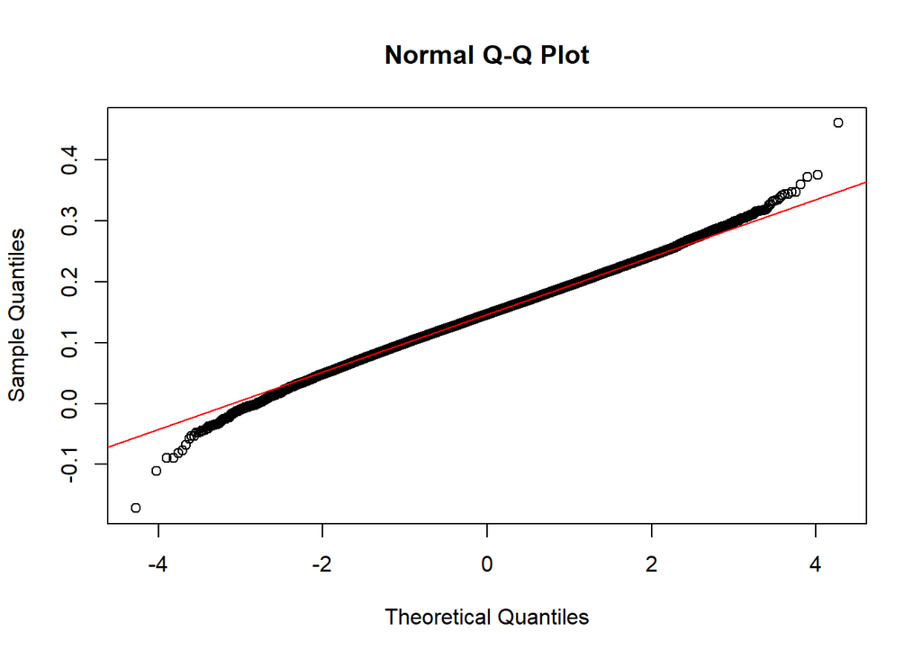

```r
# Extract posterior estimates for the critical interaction effect from the brms
# model (pull converts it to a numerical vector):
beta_posterior <- pull(posterior_samples(bfm_orig, "b_mv_wt"))
# check normality
qqnorm(beta_posterior)
qqline(beta_posterior,col='red')
```

```r
moments::kurtosis(beta_posterior)
```

```
## [1] 3.352093
```

```r
moments::skewness(beta_posterior)
```

```
## [1] -0.04010556
```

```r
# We may safely assume normality. NB: Shapiro test doesn't work if
# length(v) > 5000, and is problematic for other reasons as well. See:
# https://stats.stackexchange.com/questions/2492/is-normality-testing-essentially-useless
mean_inter_post <- mean(beta_posterior)
mean_inter_post
```

```
## [1] 0.1458637
```

```r
sd_inter_post   <- sd(beta_posterior)
sd_inter_post
```

```
## [1] 0.04829117
```

```r
# Load simulate_binom() function
source("generate_data_fnc.R")
```

# 3 Generate data

## 3.1 Set simulation parameters

```r
# Fixed (i.e., population-level) effects:
fixef(bfm_orig)
```

```
##              Estimate  Est.Error       Q2.5       Q97.5
## Intercept -0.86458049 0.21966535 -1.3073151 -0.43108024
## mv         0.01715228 0.10360703 -0.1914974  0.22085650
## wt        -0.05333050 0.05138847 -0.1561496  0.04765609
## mv_wt      0.14586369 0.04829117  0.0499897  0.24012152
```

```r
# Vector of coefficient means for fixed effects
fixef_means <- fixef(bfm_orig)[, 1]
fixef_means
```

```
##   Intercept          mv          wt       mv_wt
## -0.86458049  0.01715228 -0.05333050  0.14586369
```

```r
# SEMs for fixed effects. These we take from the covariance matrix (Sigma) of
# the model. Note we need to square the SEMs to convert them to variances, which
# is what our simulate_binom() function expects (rather than SD).
fixef_sigma <- diag(fixef(bfm_orig)[, 2] ^ 2)  # we assume uncorrelated diagonal matrix
fixef_sigma
```

```
##            [,1]       [,2]        [,3]        [,4]
## [1,] 0.04825286 0.00000000 0.000000000 0.000000000
## [2,] 0.00000000 0.01073442 0.000000000 0.000000000
## [3,] 0.00000000 0.00000000 0.002640774 0.000000000
## [4,] 0.00000000 0.00000000 0.000000000 0.002332037
```

```r
# By-subject random effects for the model:
VarCorr(bfm_orig)$subject$sd
```

```
##             Estimate  Est.Error        Q2.5     Q97.5
## Intercept 0.81197051 0.19692660 0.518310920 1.2788021
## mv        0.34912933 0.09571024 0.200702915 0.5756546
## wt        0.08992448 0.06241663 0.004097095 0.2352066
## mv_wt     0.06787147 0.05198945 0.002839334 0.1928925
```

```r
# Extract by-subject random SDs and square them to obtain variances:
ranef_sigma_subj <- diag(VarCorr(bfm_orig)$subject$sd[, 1]) ^ 2
ranef_sigma_subj
```

```
##           [,1]      [,2]        [,3]        [,4]
## [1,] 0.6592961 0.0000000 0.000000000 0.000000000
## [2,] 0.0000000 0.1218913 0.000000000 0.000000000
## [3,] 0.0000000 0.0000000 0.008086413 0.000000000
## [4,] 0.0000000 0.0000000 0.000000000 0.004606536
```

```r
# The original data consists of aggregated by-subject data, not trial-level data.
# To obtain estimates for item-level variability we use our own pilot data (see
# https://github.com/montero-melis/2018_replication_sheb-pulv2013/blob/master/1806_pilot_analysis/item-variance_estimates.R).
# The random by-item intercept is SD=0.65. However, we don't have estimates for
# by-item random slope for movement because we only ran the control condition in
# the pilot. We will assume the SD for this random slope to be the same as the
# by-subject SD for the slope of the critical interaction, which is likely to be
# an overestimate. If so, it will only make our power estimates more conservative:
ranef_sigma_item <- diag(c(0.65, 0.06)) ^ 2  # square to obtain variances
ranef_sigma_item
```

```
##        [,1]   [,2]
## [1,] 0.4225 0.0000
## [2,] 0.0000 0.0036
```

## 3.2 Simulate data

```r
# Simulate data
set.seed(654198461)  # make data set replicable
d <- simulate_binom(
  Nsubj = 60,
  Nitem = 104,
  fixef_means = fixef_means,
  fixef_sigma = fixef_sigma,
  ranef_sigma_subj = ranef_sigma_subj,
  ranef_sigma_item = ranef_sigma_item
)
```

The output is a data frame with the simulated data:

```r
head(d) %>% kable
```

| subject | block | trial_in_exp | movement | word_type | item | pos_in_trial | preced_error | Error | LO_fixef | LO_subj | LO_item | LO | prob |
| --- | --- | --- | --- | --- | --- | --- | --- | --- | --- | --- | --- | --- | --- |
| 1 | 1 | 1 | arms | leg-word | 102 | 1 | 0 | 0 | -1.025769 | -0.1766619 | 0.1731217 | -1.0293088 | 0.2632181 |
| 1 | 1 | 1 | arms | leg-word | 101 | 2 | 0 | 1 | -1.025769 | -0.1766619 | 1.1966490 | -0.0057815 | 0.4985546 |
| 1 | 1 | 1 | arms | leg-word | 68 | 3 | 1 | 0 | -1.025769 | -0.1766619 | -0.4003757 | -1.6028062 | 0.1675898 |
| 1 | 1 | 1 | arms | leg-word | 79 | 4 | 1 | 0 | -1.025769 | -0.1766619 | -0.4655314 | -1.6679619 | 0.1586961 |
| 1 | 1 | 2 | arms | leg-word | 104 | 1 | 0 | 0 | -1.025769 | -0.1766619 | 0.8639232 | -0.3385073 | 0.4161721 |
| 1 | 1 | 2 | arms | leg-word | 82 | 2 | 0 | 0 | -1.025769 | -0.1766619 | -0.0773834 | -1.2798139 | 0.2175819 |

This data frame contains columns that decompose each observation into the parameters that generated it. These parameters reflect effects at three different levels: population-, participant-, and item-level effects. In the real data set we would only observe the actual outcome and would have to infer the rest. So the actual data will look like this:

```r
d %>% select(subject : Error) %>% head %>% kable
```

| subject | block | trial_in_exp | movement | word_type | item | pos_in_trial | preced_error | Error |
| --- | --- | --- | --- | --- | --- | --- | --- | --- |
| 1 | 1 | 1 | arms | leg-word | 102 | 1 | 0 | 0 |
| 1 | 1 | 1 | arms | leg-word | 101 | 2 | 0 | 1 |
| 1 | 1 | 1 | arms | leg-word | 68 | 3 | 1 | 0 |
| 1 | 1 | 1 | arms | leg-word | 79 | 4 | 1 | 0 |
| 1 | 1 | 2 | arms | leg-word | 104 | 1 | 0 | 0 |
| 1 | 1 | 2 | arms | leg-word | 82 | 2 | 0 | 0 |

## 3.3 Simulate sequential data collection

Our design is sequential:

1. Collect data from $N_{min}=60$ participants.
2. Compute standard $BF$ (weakly informative prior) for alternative hypothesis (interaction $\neq 0$) vs null hypothesis (interaction $= 0$).
3. If either $BF_{10} > 6$ or $BF_{01} > 6$, stop data collection and report results. Else:
4. If $N<108$, collect another batch of 12 participants and go to step 2. Else:
5. When we reach $N=108$, stop data collection, compute $BF$ and report results.

We therefore first analyze a data set of $N_{min}=60$ participants:

```r
d_60 <- d %>% filter(subject %in% 1 : 60)
```

# 4 Analyze and plot data (analysis pipeline)

We show the data analysis pipeline for a data set corresponding to a sample size of $N=60$. If the Bayes factor was below our pre-determined evidence threshold ($\frac{1}{6} < BF_{10} < 6$), then we would collect an additional batch of 12 participants and repeat the same analysis.

## 4.1 Function for data analysis

Create a function that streamlines data processing and model fitting:

```r
analyse_pipe <- function(
  df,            # expects the data frame in above format
  repBF = FALSE  # compute replication BF?
  ) {

  df_name <- deparse(substitute(df))  # to use for filename later
  if (repBF) { df_name <- paste(df_name, "repBF", sep = "_") }

  # Drop superfluous columns (those that won't be in the actual data)
  df <- select(df, subject : Error)

  # coding scheme: contrast code factors and standardize numerical predictors
  contrasts(df$movement) <- contr.sum(2)
  colnames(contrasts(df$movement)) <- "arms_vs_legs"
  print(contrasts(df$movement))

  contrasts(df$word_type) <- contr.sum(2)
  colnames(contrasts(df$word_type)) <- "arms_vs_legs"
  print(contrasts(df$word_type))

  df$trial_in_exp_z <- scale(df$trial_in_exp)
  df$pos_in_trial_z <- scale(df$pos_in_trial)
  df$preced_error_z <- scale(df$preced_error)

  # Formula of the full model:
  formula_full <- as.formula(paste(
    "Error ~",  # DV
    "1 + movement * word_type +",  # critical manipulations and interaction
    "trial_in_exp_z + pos_in_trial_z + preced_error_z +",  # nuisance predictors
    "(1 + movement * word_type | subject) + (1 + movement | item)"  # maximal random structure
  ))
  print(formula_full)
  # Formula of the null model (remove the population-level interaction)
  formula_null <- update(formula_full, ~ . - movement : word_type)
  print(formula_null)

  # Priors:
  # As default, specify weakly informative priors: N(0,sigma^2 = 4) for
  # population-level (fixed) effects
  # NB: In Stan a normal distribution is specified with sigma (*not* sigma^2), see
  # https://mc-stan.org/docs/2_18/functions-reference/normal-distribution.html
  # and
  # https://stackoverflow.com/questions/52893379/stan-in-r-standard-deviation-or-variance-in-normal-distribution
  # Print to screen the priors that can be specified for full and null models:
  print(get_prior(formula_full, df))
  print(get_prior(formula_null, df))
  # Set weakly informative priors
  myprior <- set_prior("normal(0, 2)", class = "b")
  print("myprior:")
  print(myprior)
  # for replication BF, use the posterior of the re-analysis as prior for interaction:
  myprior_repBF <- c(
    myprior,
    set_prior(
      paste("normal(", mean_inter_post, ",", sd_inter_post, ")", sep = ""),
      class = "b",
      coef = "movementarms_vs_legs:word_typearms_vs_legs"
      )
    )
  print("myprior_repBF:")
  print(myprior_repBF)

  # fit null model (without interaction):
  # NB: The prior for interaction is not defined in the null model:
  bfm_null <- brm(
    formula = formula_null,
    data = df,
    prior = myprior,
    family = "bernoulli",
    iter = 15000, warmup = 2000, chains = 4,  # https://discourse.mc-stan.org/t/bayes-factor-using-brms/4469/3
    save_all_pars = TRUE  # necessary for brms::bayes_factor() later
  )
  # Model *without* interaction
  bfm_full <- update(
    bfm_null,
    formula = formula_full,
    prior = if (repBF) { myprior_repBF } else { myprior },
    )

  # pack models and data into a list and give sensible names to each object
  out <- list(bfm_full, bfm_null, df)
  names(out) <- paste(df_name, c("bfm_full", "bfm_null", "dataset"), sep = "_")

  # save list to disk:
  saveRDS(out, file = paste("data/analysis_simulated_", df_name, ".rds", sep =""))

  out
}
```

## 4.2 Fit model with weakly informative priors

Fit full and null models the first time and load them from disk later (comment/uncomment accordingly):

```r
# sim_d_60 <- analyse_pipe(d_60)  # takes about 2.5 hours
sim_d_60 <- readRDS("data/analysis_simulated_d_60.rds")
names(sim_d_60)
```

```
## [1] "d_60_bfm_full" "d_60_bfm_null" "d_60_dataset"
```

Summary of priors (sanity check):

```r
prior_summary(sim_d_60[[1]])  # full model
```

```
##                   prior     class
## 1          normal(0, 2)         b
## 2                               b
## 3                               b
## 4                               b
## 5                               b
## 6                               b
## 7   student_t(3, 0, 10) Intercept
## 8  lkj_corr_cholesky(1)         L
## 9                               L
## 10                              L
## 11  student_t(3, 0, 10)        sd
## 12                             sd
## 13                             sd
## 14                             sd
## 15                             sd
## 16                             sd
## 17                             sd
## 18                             sd
## 19                             sd
##                                          coef   group resp dpar nlpar
## 1
## 2                        movementarms_vs_legs
## 3                              pos_in_trial_z
## 4                              preced_error_z
## 5                              trial_in_exp_z
## 6                       word_typearms_vs_legs
## 7
## 8
## 9                                                item
## 10                                            subject
## 11
## 12                                               item
## 13                                  Intercept    item
## 14                       movementarms_vs_legs    item
## 15                                            subject
## 16                                  Intercept subject
## 17                       movementarms_vs_legs subject
## 18 movementarms_vs_legs:word_typearms_vs_legs subject
## 19                      word_typearms_vs_legs subject
##    bound
## 1
## 2
## 3
## 4
## 5
## 6
## 7
## 8
## 9
## 10
## 11
## 12
## 13
## 14
## 15
## 16
## 17
## 18
## 19
```

```r
prior_summary(sim_d_60[[2]])  # null model
```

```
##                   prior     class
## 1          normal(0, 2)         b
## 2                               b
## 3                               b
## 4                               b
## 5                               b
## 6                               b
## 7   student_t(3, 0, 10) Intercept
## 8  lkj_corr_cholesky(1)         L
## 9                               L
## 10                              L
## 11  student_t(3, 0, 10)        sd
## 12                             sd
## 13                             sd
## 14                             sd
## 15                             sd
## 16                             sd
## 17                             sd
## 18                             sd
## 19                             sd
##                                          coef   group resp dpar nlpar
## 1
## 2                        movementarms_vs_legs
## 3                              pos_in_trial_z
## 4                              preced_error_z
## 5                              trial_in_exp_z
## 6                       word_typearms_vs_legs
## 7
## 8
## 9                                                item
## 10                                            subject
## 11
## 12                                               item
## 13                                  Intercept    item
## 14                       movementarms_vs_legs    item
## 15                                            subject
## 16                                  Intercept subject
## 17                       movementarms_vs_legs subject
## 18 movementarms_vs_legs:word_typearms_vs_legs subject
## 19                      word_typearms_vs_legs subject
##    bound
## 1
## 2
## 3
## 4
## 5
## 6
## 7
## 8
## 9
## 10
## 11
## 12
## 13
## 14
## 15
## 16
## 17
## 18
## 19
```

## 4.3 Model summary

Full model with the critical interaction:

```r
summary(sim_d_60[[1]])
```

```
##  Family: bernoulli
##   Links: mu = logit
## Formula: Error ~ movement + word_type + trial_in_exp_z + pos_in_trial_z + preced_error_z + (1 + movement * word_type | subject) + (1 + movement | item) + movement:word_type
##    Data: df (Number of observations: 12480)
## Samples: 4 chains, each with iter = 15000; warmup = 2000; thin = 1;
##          total post-warmup samples = 52000
##
## Group-Level Effects:
## ~item (Number of levels: 104)
##                                     Estimate Est.Error l-95% CI u-95% CI
## sd(Intercept)                           0.66      0.05     0.56     0.77
## sd(movementarms_vs_legs)                0.10      0.05     0.01     0.18
## cor(Intercept,movementarms_vs_legs)    -0.13      0.31    -0.79     0.54
##                                     Rhat Bulk_ESS Tail_ESS
## sd(Intercept)                       1.00    14136    26039
## sd(movementarms_vs_legs)            1.00     8153    11418
## cor(Intercept,movementarms_vs_legs) 1.00    39365    19048
##
## ~subject (Number of levels: 60)
##                                                                       Estimate
## sd(Intercept)                                                             0.79
## sd(movementarms_vs_legs)                                                  0.35
## sd(word_typearms_vs_legs)                                                 0.05
## sd(movementarms_vs_legs:word_typearms_vs_legs)                            0.03
## cor(Intercept,movementarms_vs_legs)                                       0.09
## cor(Intercept,word_typearms_vs_legs)                                      0.03
## cor(movementarms_vs_legs,word_typearms_vs_legs)                           0.07
## cor(Intercept,movementarms_vs_legs:word_typearms_vs_legs)                 0.01
## cor(movementarms_vs_legs,movementarms_vs_legs:word_typearms_vs_legs)      0.10
## cor(word_typearms_vs_legs,movementarms_vs_legs:word_typearms_vs_legs)     0.03
##                                                                       Est.Error
## sd(Intercept)                                                              0.08
## sd(movementarms_vs_legs)                                                   0.04
## sd(word_typearms_vs_legs)                                                  0.04
## sd(movementarms_vs_legs:word_typearms_vs_legs)                             0.02
## cor(Intercept,movementarms_vs_legs)                                        0.15
## cor(Intercept,word_typearms_vs_legs)                                       0.37
## cor(movementarms_vs_legs,word_typearms_vs_legs)                            0.38
## cor(Intercept,movementarms_vs_legs:word_typearms_vs_legs)                  0.41
## cor(movementarms_vs_legs,movementarms_vs_legs:word_typearms_vs_legs)       0.42
```

[output cut: 63 more lines]

```
## pos_in_trial_z                                -0.02      0.03    -0.07
## preced_error_z                                 0.00      0.03    -0.05
## movementarms_vs_legs:word_typearms_vs_legs     0.12      0.02     0.07
##                                            u-95% CI Rhat Bulk_ESS Tail_ESS
## Intercept                                     -0.69 1.00     5564    11755
## movementarms_vs_legs                           0.12 1.00    18819    30225
## word_typearms_vs_legs                          0.11 1.00     9642    20205
## trial_in_exp_z                                 0.08 1.00    39290    42466
## pos_in_trial_z                                 0.03 1.00    77972    42761
## preced_error_z                                 0.06 1.00    69593    42191
## movementarms_vs_legs:word_typearms_vs_legs     0.17 1.00    75348    39945
##
## Samples were drawn using sampling(NUTS). For each parameter, Eff.Sample
## is a crude measure of effective sample size, and Rhat is the potential
## scale reduction factor on split chains (at convergence, Rhat = 1).
```

## 4.4 Standard Bayes factor for H1 (full model) vs H0 (null model)

Compute Bayes factor (or load from disk if run before):

```r
# # Run and save to disk
# BF_bfm_d60 <- brms::bayes_factor(
#   sim_d_60[["d_60_bfm_full"]], sim_d_60[["d_60_bfm_null"]]
#   )
# saveRDS(BF_bfm_d60, "data/BF_bfm_d60.rds")

# Once run, read from disk
BF_bfm_d60 <- readRDS("data/BF_bfm_d60.rds")
```

Standard Bayes factor comparing $H_1$ (the critical interaction is not zero) to $H_0$ (the critical interaction is zero), based on weakly informative prior:

```r
BF_bfm_d60
```

```
## Estimated Bayes factor in favor of bridge1 over bridge2: 559.67415
```

## 4.5 Plot model estimates

Plot all population-level estimates. Inner boxes show 50%, outer error bars 95% credible intervals (see detailed [plot explanation here](https://strengejacke.github.io/sjPlot/articles/plot_model_estimates.html#bayesian-models-fitted-with-stan)):

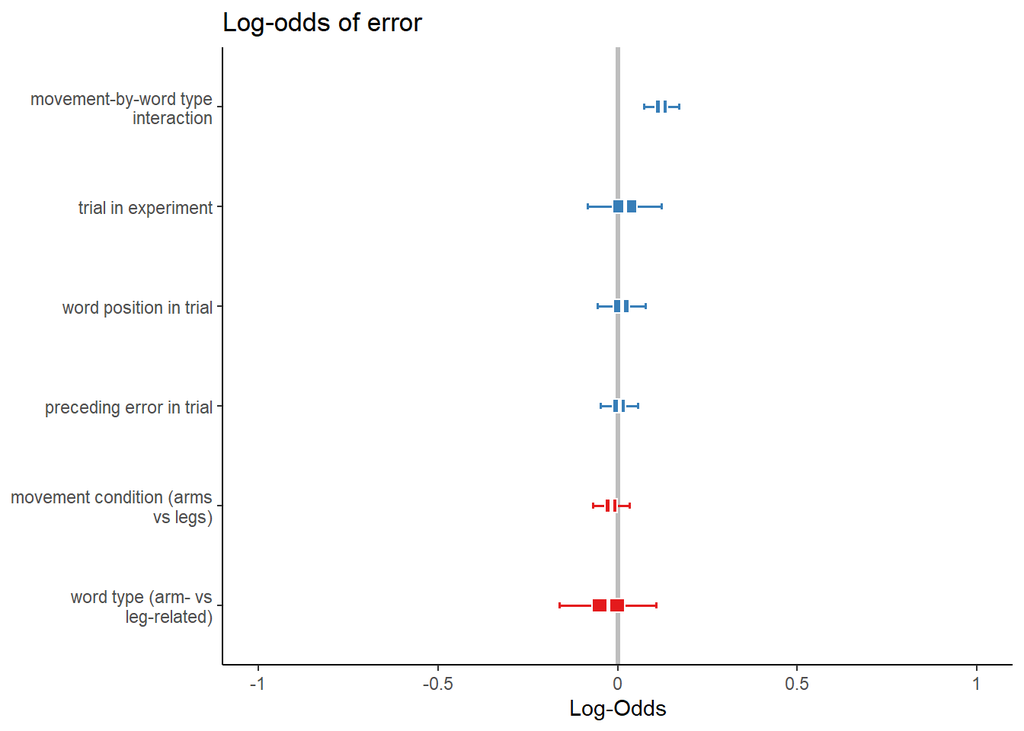

```r
sjPlot::plot_model(
  sim_d_60[[1]], transform = NULL, prob.outer = .95, sort.est = TRUE,
  vline.color = "gray", title = "Log-odds of error",
  axis.labels = c(  # Careful: indep of sort.est, the order is simply specified bottom to top!
    "word type (arm- vs leg-related)",
    "movement condition (arms vs legs)",
    "preceding error in trial",
    "word position in trial",
    "trial in experiment",
    "movement-by-word type interaction"
    )
  ) +
  theme_classic()
```

Plot the interaction effect:

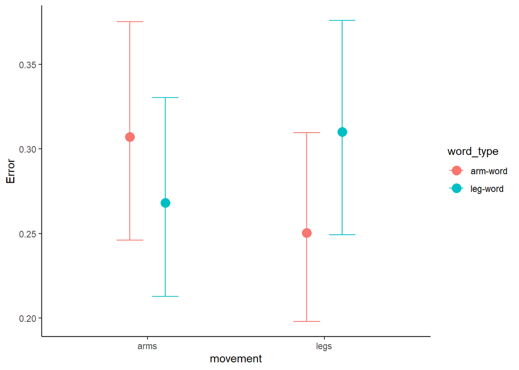

```r
plot(marginal_effects(sim_d_60[[1]], effects = "movement:word_type"),
     theme = theme_classic())
```

## 4.6 Replication Bayes factor (after Verhagen and Wagenmakers, 2014)

For $BF_{rep}$ we use as the prior for the interaction coefficient the posterior distribution from the model fitted to the original data. We specify this as a normal distribution (see “Set up workspace” for this prior and “Function for data analysis” for the actual fitting).

### 4.6.1 Fit models with appropriate prior for repBF:

Fit full and null models the first time and load them from disk later (comment/uncomment accordingly):

```r
# sim_d_60_BFrep <- analyse_pipe(d_60, repBF = TRUE)  # takes about 2  hours
sim_d_60_BFrep <- readRDS("data/analysis_simulated_d_60_repBF.rds")
names(sim_d_60_BFrep)
```

```
## [1] "d_60_repBF_bfm_full" "d_60_repBF_bfm_null" "d_60_repBF_dataset"
```

### 4.6.2 Check priors and model summary

Summary of priors:

```r
prior_summary(sim_d_60_BFrep[[1]])  # full model
```

```
##                                           prior     class
## 1                                  normal(0, 2)         b
## 2                                                       b
## 3  normal(0.145863685641209,0.0482911655051304)         b
## 4                                                       b
## 5                                                       b
## 6                                                       b
## 7                                                       b
## 8                           student_t(3, 0, 10) Intercept
## 9                          lkj_corr_cholesky(1)         L
## 10                                                      L
## 11                                                      L
## 12                          student_t(3, 0, 10)        sd
## 13                                                     sd
## 14                                                     sd
## 15                                                     sd
## 16                                                     sd
## 17                                                     sd
## 18                                                     sd
## 19                                                     sd
## 20                                                     sd
##                                          coef   group resp dpar nlpar
## 1
## 2                        movementarms_vs_legs
## 3  movementarms_vs_legs:word_typearms_vs_legs
## 4                              pos_in_trial_z
## 5                              preced_error_z
## 6                              trial_in_exp_z
## 7                       word_typearms_vs_legs
## 8
## 9
## 10                                               item
## 11                                            subject
## 12
## 13                                               item
## 14                                  Intercept    item
## 15                       movementarms_vs_legs    item
## 16                                            subject
## 17                                  Intercept subject
## 18                       movementarms_vs_legs subject
```

[output cut: 8 more lines]

```
## 6
## 7
## 8
## 9
## 10
## 11
## 12
## 13
## 14
## 15
## 16
## 17
## 18
## 19
## 20
```

```r
prior_summary(sim_d_60_BFrep[[2]])  # null model
```

```
##                   prior     class
## 1          normal(0, 2)         b
## 2                               b
## 3                               b
## 4                               b
## 5                               b
## 6                               b
## 7   student_t(3, 0, 10) Intercept
## 8  lkj_corr_cholesky(1)         L
## 9                               L
## 10                              L
## 11  student_t(3, 0, 10)        sd
## 12                             sd
## 13                             sd
## 14                             sd
## 15                             sd
## 16                             sd
## 17                             sd
## 18                             sd
## 19                             sd
##                                          coef   group resp dpar nlpar
## 1
## 2                        movementarms_vs_legs
## 3                              pos_in_trial_z
## 4                              preced_error_z
## 5                              trial_in_exp_z
## 6                       word_typearms_vs_legs
## 7
## 8
## 9                                                item
## 10                                            subject
## 11
## 12                                               item
## 13                                  Intercept    item
## 14                       movementarms_vs_legs    item
## 15                                            subject
## 16                                  Intercept subject
## 17                       movementarms_vs_legs subject
## 18 movementarms_vs_legs:word_typearms_vs_legs subject
## 19                      word_typearms_vs_legs subject
##    bound
## 1
## 2
## 3
## 4
## 5
## 6
## 7
## 8
## 9
## 10
## 11
## 12
## 13
## 14
## 15
## 16
## 17
## 18
## 19
```

Model summary (full model with interaction)

```r
summary(sim_d_60_BFrep[[1]])
```

```
##  Family: bernoulli
##   Links: mu = logit
## Formula: Error ~ movement + word_type + trial_in_exp_z + pos_in_trial_z + preced_error_z + (1 + movement * word_type | subject) + (1 + movement | item) + movement:word_type
##    Data: df (Number of observations: 12480)
## Samples: 4 chains, each with iter = 15000; warmup = 2000; thin = 1;
##          total post-warmup samples = 52000
##
## Group-Level Effects:
## ~item (Number of levels: 104)
##                                     Estimate Est.Error l-95% CI u-95% CI
## sd(Intercept)                           0.66      0.05     0.56     0.77
## sd(movementarms_vs_legs)                0.10      0.05     0.01     0.18
## cor(Intercept,movementarms_vs_legs)    -0.13      0.31    -0.78     0.53
##                                     Rhat Bulk_ESS Tail_ESS
## sd(Intercept)                       1.00    14096    26001
## sd(movementarms_vs_legs)            1.00     8008    11595
## cor(Intercept,movementarms_vs_legs) 1.00    36386    19409
##
## ~subject (Number of levels: 60)
##                                                                       Estimate
## sd(Intercept)                                                             0.79
## sd(movementarms_vs_legs)                                                  0.35
## sd(word_typearms_vs_legs)                                                 0.05
## sd(movementarms_vs_legs:word_typearms_vs_legs)                            0.03
## cor(Intercept,movementarms_vs_legs)                                       0.09
## cor(Intercept,word_typearms_vs_legs)                                      0.04
## cor(movementarms_vs_legs,word_typearms_vs_legs)                           0.07
## cor(Intercept,movementarms_vs_legs:word_typearms_vs_legs)                 0.01
## cor(movementarms_vs_legs,movementarms_vs_legs:word_typearms_vs_legs)      0.10
## cor(word_typearms_vs_legs,movementarms_vs_legs:word_typearms_vs_legs)     0.03
##                                                                       Est.Error
## sd(Intercept)                                                              0.08
## sd(movementarms_vs_legs)                                                   0.04
## sd(word_typearms_vs_legs)                                                  0.04
## sd(movementarms_vs_legs:word_typearms_vs_legs)                             0.02
## cor(Intercept,movementarms_vs_legs)                                        0.15
## cor(Intercept,word_typearms_vs_legs)                                       0.37
## cor(movementarms_vs_legs,word_typearms_vs_legs)                            0.38
## cor(Intercept,movementarms_vs_legs:word_typearms_vs_legs)                  0.41
## cor(movementarms_vs_legs,movementarms_vs_legs:word_typearms_vs_legs)       0.42
```

[output cut: 63 more lines]

```
## pos_in_trial_z                                -0.02      0.03    -0.07
## preced_error_z                                 0.00      0.03    -0.05
## movementarms_vs_legs:word_typearms_vs_legs     0.13      0.02     0.08
##                                            u-95% CI Rhat Bulk_ESS Tail_ESS
## Intercept                                     -0.69 1.00     5945    11500
## movementarms_vs_legs                           0.12 1.00    18916    27719
## word_typearms_vs_legs                          0.11 1.00     9645    18581
## trial_in_exp_z                                 0.08 1.00    36539    40294
## pos_in_trial_z                                 0.03 1.00    72798    42288
## preced_error_z                                 0.06 1.00    69255    43463
## movementarms_vs_legs:word_typearms_vs_legs     0.17 1.00    82892    41316
##
## Samples were drawn using sampling(NUTS). For each parameter, Eff.Sample
## is a crude measure of effective sample size, and Rhat is the potential
## scale reduction factor on split chains (at convergence, Rhat = 1).
```

### 4.6.3 Replication BF ($BF_{rep}$)

Compute replication Bayes factor (or load from disk if run before):

```r
# # Run and save to disk
# BFrep_bfm_d60 <- brms::bayes_factor(
#   sim_d_60_BFrep[[1]], sim_d_60_BFrep[[2]]
#   )
# saveRDS(BFrep_bfm_d60, "data/BFrep_bfm_d60.rds")

# Once run, read from disk
BFrep_bfm_d60 <- readRDS("data/BFrep_bfm_d60.rds")
```

$BF_{rep}$:

```r
BFrep_bfm_d60
```

```
## Estimated Bayes factor in favor of bridge1 over bridge2: 20838.50762
```

The replication BF is $BF_{rep} = 2.0839\times 10^{4} \geq 6$.